# 231B Section 3

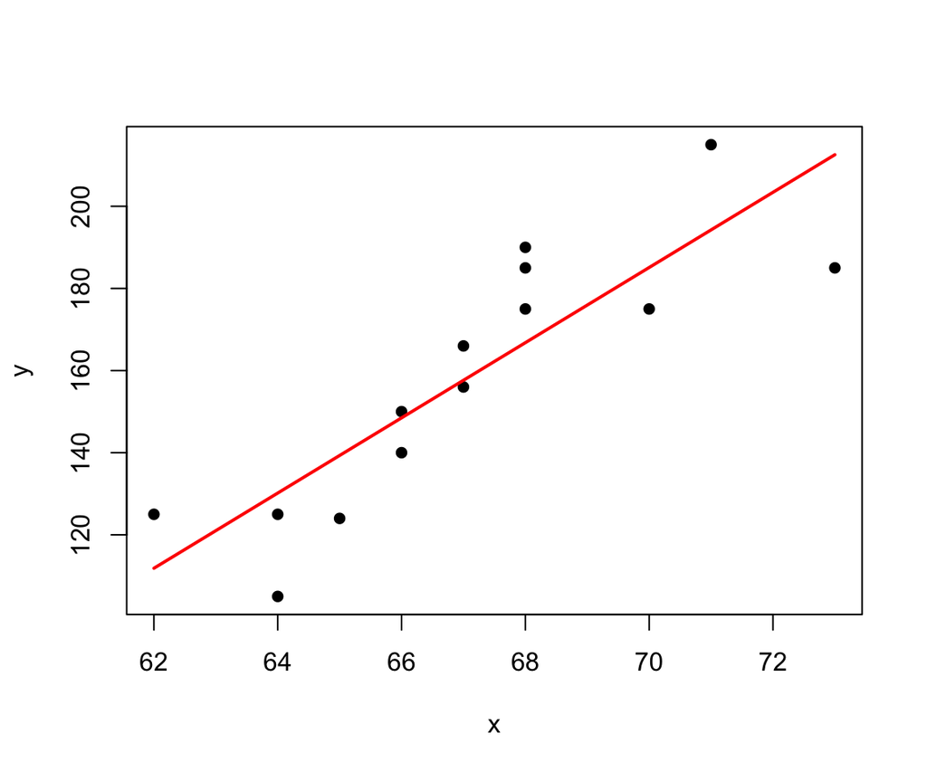

```r
regline(y=family$weight, x=family$height)
```

It is important that you understand the syntax line we use to add the regression line!

```r
  lines(x, (coefs[1]+coefs[2]*x), col="red", lwd=2)
```

What is the `y` argument here?

E. One last step! Let’s add the SD line to the plot as well. Modify `regline()` including one or more lines of code that add the SD line to the plot.

Hint: How do we calculate the slope of the SD line? What property of the SD line do we need to calculate the intercept?

```r
regline <- function(y, x){
  # This function plots a scatterplot with the regression line in red and
  # the SD line in blue.
  }
```

The only output of the function should be the plot. Please save your plots and drop them here: https://dbinbox.com/231B

One way of doing this:

```r
regline <- function(y, x){
  # This function plots a scatterplot with the regression line in red and
  # the SD line in blue.

  coefs <- regcoef(y, x)

  plot(x, y, pch=16)
  lines(x, (coefs[1]+coefs[2]*x), col="red", lwd=2)

  # SD LINE
  # slope of the SD line
  sign <- cor(y,x)/abs(cor(y,x))
  b <- (sd(y)/sd(x))*sign
  # intercept of the SD line
  a <- mean(y)-b*mean(x)
  # adding the line to the plot
  lines(x, a+b*x, col="blue", lwd=2)

  # and just for completion let's add grey lines for the mean of x and y
  abline(v=mean(x), col="grey")
  abline(h=mean(y), col="grey")
  }
```

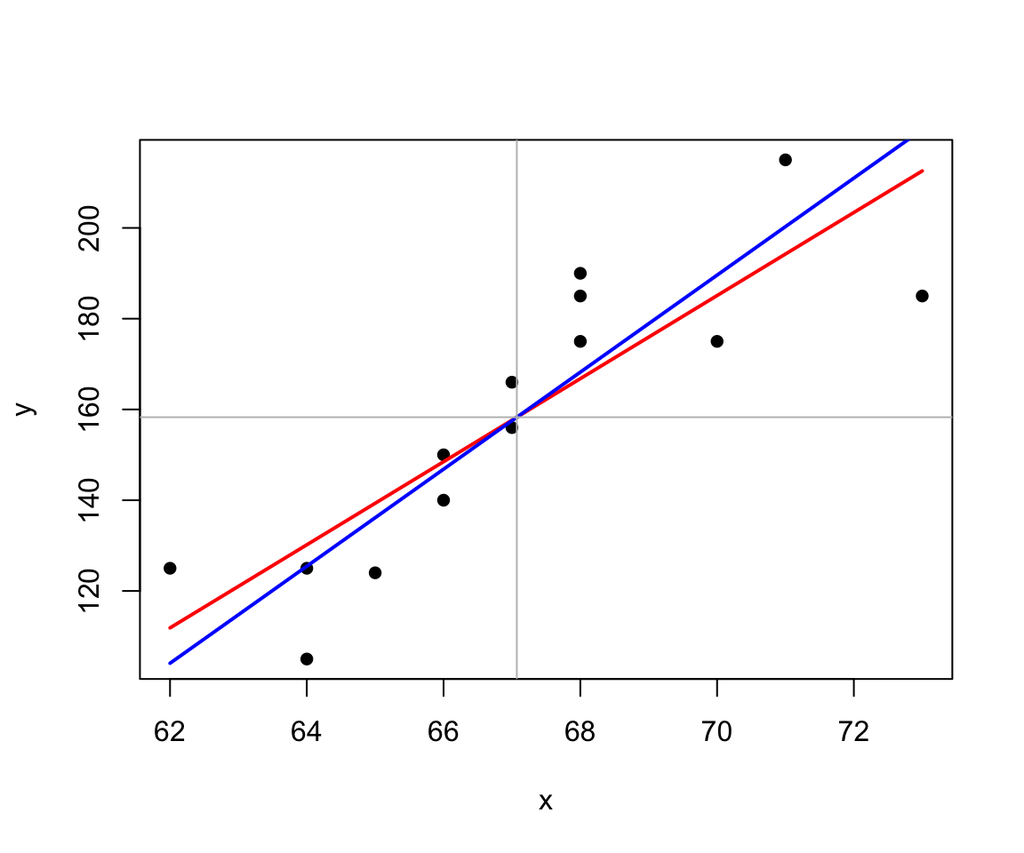

```r
regline(y=family$weight, x=family$height)
```

Why are the regression and SD lines quite similar here?

- Because the correlation between `x` and `y` here ir 0.8562259. With a weaker correlation, lines would diverge more.

# Multivariate regression

Now we will use height and bmi to predict weight. This is the plot we had, except now the size of the points is proportional to bmi. Any pattern here?

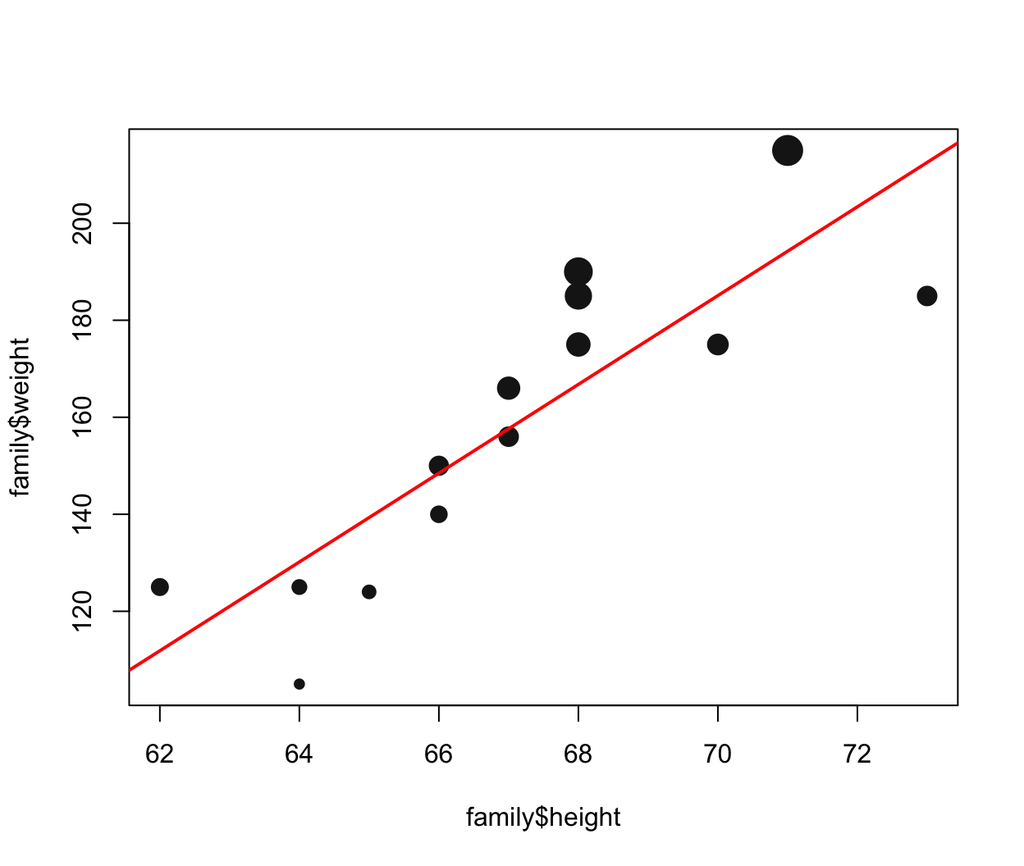

(The interest in regressing weight on height and BMI is dubious, as BMI is closely related to weight…)

# Calculating multivariate regression coefficients with matrix algebra

From lecture, we know $\hat{\beta}=(X'X)^{-1} X'Y$.

We will use this to calculate $\hat{\beta}$ “by hand” in `R`.

For this, we will need `X` and `Y`. What should the dimensions of each of these be? How do we build them?

`Y` is easy. We just need a vector with the values for `weight`.

```r
Y <- as.matrix(family$weight)

Y
```

```
##       [,1]
##  [1,]  175
##  [2,]  125
##  [3,]  185
##  [4,]  156
##  [5,]  105
##  [6,]  190
##  [7,]  185
##  [8,]  124
##  [9,]  175
## [10,]  215
## [11,]  166
## [12,]  140
## [13,]  150
## [14,]  125
```

What about `X`?

We will need to add a column of `1s` for the intercept and bind it to the `height` and `bmi` vectors.

Do we `rbind` or `cbind`??

```r
X <- as.matrix(cbind(1, family$height, family$bmi))

dim(X)
```

```
## [1] 14  3
```

```r
X
```

```
##       [,1] [,2]     [,3]
##  [1,]    1   70 25.16239
##  [2,]    1   64 21.50106
##  [3,]    1   73 24.45884
##  [4,]    1   67 24.48414
##  [5,]    1   64 18.06089
##  [6,]    1   68 28.94981
##  [7,]    1   68 28.18797
##  [8,]    1   65 20.67783
##  [9,]    1   68 26.66430
## [10,]    1   71 30.04911
## [11,]    1   67 26.05364
## [12,]    1   66 22.64384
## [13,]    1   66 24.26126
## [14,]    1   62 22.91060
```

**Exercise** Find $\beta$. Hints: `t()`, `%*%`, `det()`, `solve()`.

Let’s do this by parts.

Part 1: $(X'X)$

```r
XprimeX <- t(X) %*% X

dim(XprimeX)
```

```
## [1] 3 3
```

```r
XprimeX
```

```
##          [,1]     [,2]       [,3]
## [1,]  14.0000   939.00   344.0657
## [2,] 939.0000 63093.00 23157.1391
## [3,] 344.0657 23157.14  8598.5444
```

What does this matrix give us?

What happens when we get the inverse?

Part 2: $(X'Y)$

```r
XprimeY <- t(X) %*% Y

dim(XprimeY)
```

```
## [1] 3 1
```

```r
XprimeY
```

```
##           [,1]
## [1,]   2216.00
## [2,] 149664.00
## [3,]  55736.01
```

What about this one?

Let’s put all of this together

```r
(solve(XprimeX)) %*% XprimeY
```

```
##             [,1]
## [1,] -310.346943
## [2,]    4.675473
## [3,]    6.308645
```

```r
lm(Y~X[,2:3])
```

```
##
## Call:
## lm(formula = Y ~ X[, 2:3])
##
## Coefficients:
## (Intercept)    X[, 2:3]1    X[, 2:3]2
##    -310.347        4.675        6.309
```

# The column space of X

The “column space of $X$”, $S(X)$, is the collection of all the points that can be expressed as $X\beta$, ie. that can be written as linear combinations of the columns in $X$. When $X$ is a matrix with two independent variables, this collection of points is a plane.

The column space of X

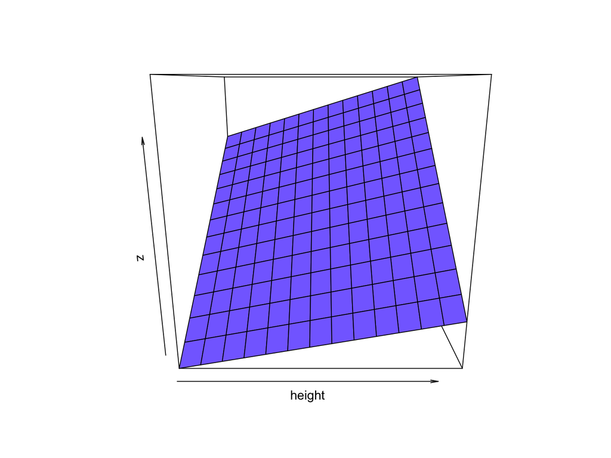

The column space of X

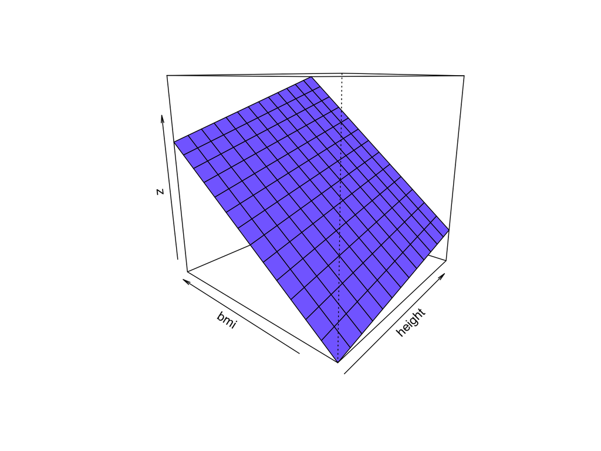

The column space of X

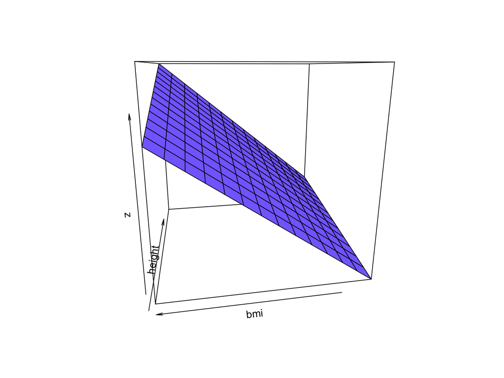

Observations

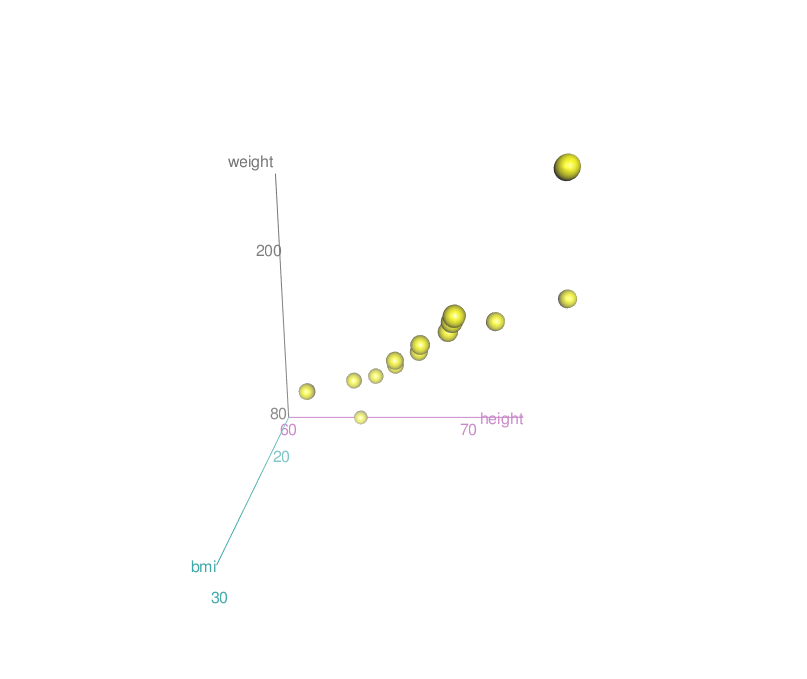

Observations + column space of $X$

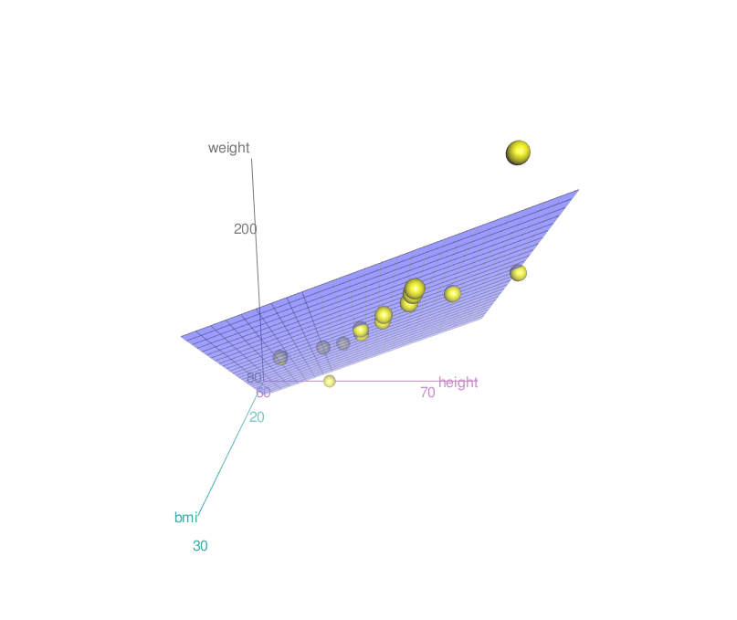

The OLS problem: given $X$ and $Y$, find $\hat{Y}$, the points on $S(X)$ that are closest to $Y$. $\hat{Y}$ is often called the “orthogonal projection” of $Y$ onto the column space of $X$.

Orthogonal projection of $Y$ onto $S(X)$

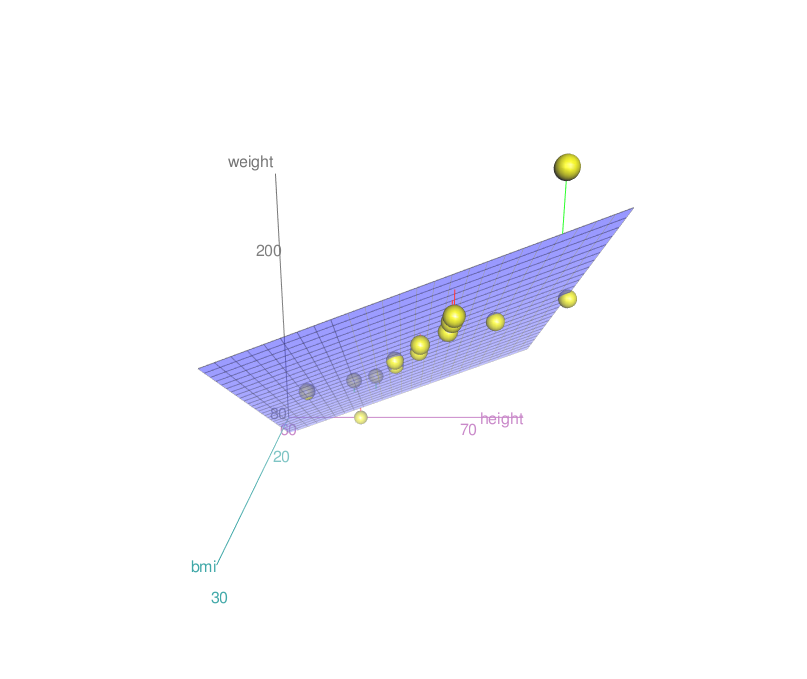